# ME314 2018 Exam

Ken Benoit, Slava Mikhaylov, and Jack Blumenau

**INSTRUCTIONS:** Answer **four** of the **five** questions. If you answer five, we will base your grade on the best four of five. Each of your four best questions is weighted equally in the determination of your overall grade. (25 points each)

```r
# loading packages
library(quanteda) # textual processing
library(caret) # model processing, training and selection
library(tidyverse) # data management
library(stm) # structural topic model
library(class) # for kNN
library(e1071) # for naive bayes
library(boot) # for bootstrapping
set.seed(10101)
```

### Question 1

Using the `Boston` dataset (`MASS` package), predict the per capita crime rate using the other variables in this data set. In other words, per capita crime rate is the response, and the other variables are the predictors.

```r
data(Boston, package = "MASS")
head(Boston)
```

```
##      crim zn indus chas   nox    rm  age    dis rad tax ptratio  black
## 1 0.00632 18  2.31    0 0.538 6.575 65.2 4.0900   1 296    15.3 396.90
## 2 0.02731  0  7.07    0 0.469 6.421 78.9 4.9671   2 242    17.8 396.90
## 3 0.02729  0  7.07    0 0.469 7.185 61.1 4.9671   2 242    17.8 392.83
## 4 0.03237  0  2.18    0 0.458 6.998 45.8 6.0622   3 222    18.7 394.63
## 5 0.06905  0  2.18    0 0.458 7.147 54.2 6.0622   3 222    18.7 396.90
## 6 0.02985  0  2.18    0 0.458 6.430 58.7 6.0622   3 222    18.7 394.12
##   lstat medv
## 1  4.98 24.0
## 2  9.14 21.6
## 3  4.03 34.7
## 4  2.94 33.4
## 5  5.33 36.2
## 6  5.21 28.7
```

1. For each predictor, fit a simple (single-variable) linear regression model to predict the response. In which of the models is there a statistically significant association between the predictor and the response?

```r
Boston.lm.coefficients <- vector(mode = "numeric", length = 13)

for (i in 2:14) {
  lm.fit <- lm(Boston$crim ~ Boston[, i])
  Boston.lm.coefficients[i - 1] <- coef(lm.fit)[2]

  print(paste0("For predictor:", colnames(Boston)[i]))
  print(summary(lm.fit))
}
```

```
## [1] "For predictor:zn"
##
## Call:
## lm(formula = Boston$crim ~ Boston[, i])
##
## Residuals:
##    Min     1Q Median     3Q    Max
## -4.429 -4.222 -2.620  1.250 84.523
##
## Coefficients:
##             Estimate Std. Error t value Pr(>|t|)
## (Intercept)  4.45369    0.41722  10.675  < 2e-16 ***
## Boston[, i] -0.07393    0.01609  -4.594 5.51e-06 ***
## ---
## Signif. codes:  0 '***' 0.001 '**' 0.01 '*' 0.05 '.' 0.1 ' ' 1
##
## Residual standard error: 8.435 on 504 degrees of freedom
## Multiple R-squared:  0.04019,    Adjusted R-squared:  0.03828
## F-statistic:  21.1 on 1 and 504 DF,  p-value: 5.506e-06
##
## [1] "For predictor:indus"
##
## Call:
## lm(formula = Boston$crim ~ Boston[, i])
##
## Residuals:
##     Min      1Q  Median      3Q     Max
## -11.972  -2.698  -0.736   0.712  81.813
##
## Coefficients:
##             Estimate Std. Error t value Pr(>|t|)
## (Intercept) -2.06374    0.66723  -3.093  0.00209 **
## Boston[, i]  0.50978    0.05102   9.991  < 2e-16 ***
## ---
## Signif. codes:  0 '***' 0.001 '**' 0.01 '*' 0.05 '.' 0.1 ' ' 1
##
## Residual standard error: 7.866 on 504 degrees of freedom
## Multiple R-squared:  0.1653, Adjusted R-squared:  0.1637
## F-statistic: 99.82 on 1 and 504 DF,  p-value: < 2.2e-16
##
```

[output cut: 204 more lines]

```
##
## Residuals:
##    Min     1Q Median     3Q    Max
## -9.071 -4.022 -2.343  1.298 80.957
##
## Coefficients:
##             Estimate Std. Error t value Pr(>|t|)
## (Intercept) 11.79654    0.93419   12.63   <2e-16 ***
## Boston[, i] -0.36316    0.03839   -9.46   <2e-16 ***
## ---
## Signif. codes:  0 '***' 0.001 '**' 0.01 '*' 0.05 '.' 0.1 ' ' 1
##
## Residual standard error: 7.934 on 504 degrees of freedom
## Multiple R-squared:  0.1508, Adjusted R-squared:  0.1491
## F-statistic: 89.49 on 1 and 504 DF,  p-value: < 2.2e-16
```

```
Interestingly, except for the predictor chas (which is the Charles River dummy variable), every other single-variable linear regression model have a statistically significant association between the predictor and the response at the p < 0.001 level.
```

2. Fit a multiple regression model to predict the response using all of the predictors. Describe your results. For which predictors can we reject the null hypothesis $H_0 : \beta_j = 0$?

```r
Boston.mlm <- lm(formula = crim ~ .,
                   data = Boston)
summary(Boston.mlm)
```

```
##
## Call:
## lm(formula = crim ~ ., data = Boston)
##
## Residuals:
##    Min     1Q Median     3Q    Max
## -9.924 -2.120 -0.353  1.019 75.051
##
## Coefficients:
##               Estimate Std. Error t value Pr(>|t|)
## (Intercept)  17.033228   7.234903   2.354 0.018949 *
## zn            0.044855   0.018734   2.394 0.017025 *
## indus        -0.063855   0.083407  -0.766 0.444294
## chas         -0.749134   1.180147  -0.635 0.525867
## nox         -10.313535   5.275536  -1.955 0.051152 .
## rm            0.430131   0.612830   0.702 0.483089
## age           0.001452   0.017925   0.081 0.935488
## dis          -0.987176   0.281817  -3.503 0.000502 ***
## rad           0.588209   0.088049   6.680 6.46e-11 ***
## tax          -0.003780   0.005156  -0.733 0.463793
## ptratio      -0.271081   0.186450  -1.454 0.146611
## black        -0.007538   0.003673  -2.052 0.040702 *
## lstat         0.126211   0.075725   1.667 0.096208 .
## medv         -0.198887   0.060516  -3.287 0.001087 **
## ---
## Signif. codes:  0 '***' 0.001 '**' 0.01 '*' 0.05 '.' 0.1 ' ' 1
##
## Residual standard error: 6.439 on 492 degrees of freedom
## Multiple R-squared:  0.454,  Adjusted R-squared:  0.4396
## F-statistic: 31.47 on 13 and 492 DF,  p-value: < 2.2e-16
```

[output not shown]

3. How do your results from (a) compare to your results from (b)? Create a plot displaying the univariate regression coefficients from (a) on the $x$-axis, and the multiple regression coefficients from (b) on the $y$-axis. That is, each predictor is displayed as a single point in the plot. Its coefficient in a simple linear regression model is shown on the $x$-axis, and its coefficient estimate in the multiple linear regression model is shown on the $y$-axis. Hint: To get the coefficients from a fitted regression model, you can use `coef()`. Note that you are not interested in the intercept.

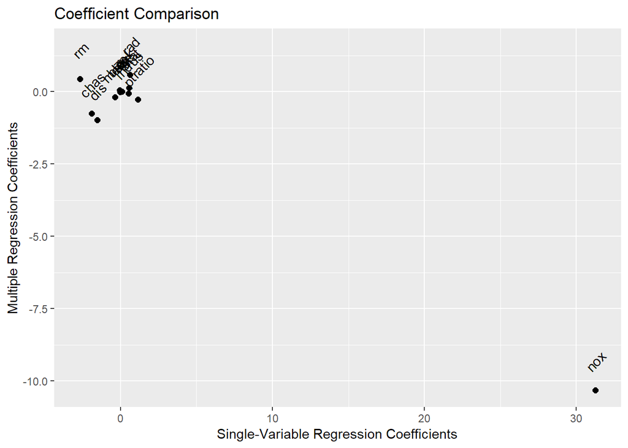

[output not shown]

```r
Boston.mlm.coefficients <- coef(Boston.mlm)[2:14]
q1 <- ggplot(data = NULL, aes(x = Boston.lm.coefficients,
                              y = Boston.mlm.coefficients,
                              label = colnames(Boston)[2:14])) +
      geom_point(size = 2, shape = 19) +
      geom_text(angle = 45, nudge_y = 1) +
      labs(x = "Single-Variable Regression Coefficients", y = "Multiple Regression Coefficients",
           title = "Coefficient Comparison")
q1
```

### Question 2

Using the `Boston` data set, fit classification models in order to predict whether a given suburb has a crime rate above or below the median. Produce a confusion matrix for, and describe the findings from your model, for each of:

```r
BostonCrimMedian <- Boston
BostonCrimMedian$crim <- as.numeric(BostonCrimMedian$crim > median(BostonCrimMedian$crim)) #1 if above

trainIndex <- createDataPartition(BostonCrimMedian$crim, p = 0.75, list = FALSE)

BostonCrimMedian.train <- BostonCrimMedian[trainIndex, ]
BostonCrimMedian.test <- BostonCrimMedian[-trainIndex, ]
```

1. logistic regression

```r
BostonCrimMedian.lr <- glm(formula = crim ~ .,
                           data = BostonCrimMedian.train,
                           family = binomial)
summary(BostonCrimMedian.lr)
```

```
##
## Call:
## glm(formula = crim ~ ., family = binomial, data = BostonCrimMedian.train)
##
## Deviance Residuals:
##      Min        1Q    Median        3Q       Max
## -2.28116  -0.09674  -0.00011   0.00044   2.27078
##
## Coefficients:
##               Estimate Std. Error z value Pr(>|z|)
## (Intercept) -44.178037   8.116078  -5.443 5.23e-08 ***
## zn           -0.093226   0.043990  -2.119 0.034067 *
## indus        -0.077099   0.052624  -1.465 0.142890
## chas          0.843946   0.957797   0.881 0.378246
## nox          61.980924  10.107056   6.132 8.65e-10 ***
## rm           -0.698563   0.856159  -0.816 0.414542
## age           0.020622   0.015187   1.358 0.174495
## dis           0.967588   0.279814   3.458 0.000544 ***
## rad           0.851003   0.200454   4.245 2.18e-05 ***
## tax          -0.008600   0.003427  -2.510 0.012085 *
## ptratio       0.507757   0.156346   3.248 0.001164 **
## black        -0.010575   0.005638  -1.876 0.060701 .
## lstat         0.015617   0.061040   0.256 0.798063
## medv          0.180509   0.081155   2.224 0.026132 *
## ---
## Signif. codes:  0 '***' 0.001 '**' 0.01 '*' 0.05 '.' 0.1 ' ' 1
##
## (Dispersion parameter for binomial family taken to be 1)
##
##     Null deviance: 526.79  on 379  degrees of freedom
## Residual deviance: 145.86  on 366  degrees of freedom
## AIC: 173.86
##
## Number of Fisher Scoring iterations: 9
```

```r
BostonCrimMedian.lr.pred <- as.numeric(predict(BostonCrimMedian.lr, type = "response", newdata = BostonCrimMedian.test) > 0.5)
confusionMatrix(data = factor(BostonCrimMedian.lr.pred), reference = factor(BostonCrimMedian.test$crim))
```

```
## Confusion Matrix and Statistics
##
##           Reference
## Prediction  0  1
##          0 56  6
##          1  7 57
##
##                Accuracy : 0.8968
##                  95% CI : (0.83, 0.9439)
##     No Information Rate : 0.5
##     P-Value [Acc > NIR] : <2e-16
##
##                   Kappa : 0.7937
##  Mcnemar's Test P-Value : 1
##
##             Sensitivity : 0.8889
##             Specificity : 0.9048
##          Pos Pred Value : 0.9032
##          Neg Pred Value : 0.8906
##              Prevalence : 0.5000
##          Detection Rate : 0.4444
##    Detection Prevalence : 0.4921
##       Balanced Accuracy : 0.8968
##
##        'Positive' Class : 0
##
```

[output not shown]

2. kNN

```r
BostonCrimMedian.knn.fitControl <- trainControl(method = "repeatedcv", # 10-fold CV
                                                number = 10,
                                                repeats = 10) # repeated ten times

BostonCrimMedian.knn.fit <- train(factor(crim) ~ ., data = BostonCrimMedian.train,
                                  method = "knn",
                                  trControl = BostonCrimMedian.knn.fitControl,
                                  tuneGrid =  data.frame("k" = 1:15))
BostonCrimMedian.knn.fit
```

```
## k-Nearest Neighbors
##
## 380 samples
##  13 predictor
##   2 classes: '0', '1'
##
## No pre-processing
## Resampling: Cross-Validated (10 fold, repeated 10 times)
## Summary of sample sizes: 342, 342, 342, 342, 342, 342, ...
## Resampling results across tuning parameters:
##
##   k   Accuracy   Kappa
##    1  0.9144737  0.8289474
##    2  0.8955263  0.7910526
##    3  0.9178947  0.8357895
##    4  0.9034211  0.8068421
##    5  0.9123684  0.8247368
##    6  0.8989474  0.7978947
##    7  0.8900000  0.7800000
##    8  0.8792105  0.7584211
##    9  0.8771053  0.7542105
##   10  0.8678947  0.7357895
##   11  0.8586842  0.7173684
##   12  0.8521053  0.7042105
##   13  0.8528947  0.7057895
##   14  0.8518421  0.7036842
##   15  0.8513158  0.7026316
##
## Accuracy was used to select the optimal model using the largest value.
## The final value used for the model was k = 3.
```

```r
confusionMatrix(data = factor(predict(BostonCrimMedian.knn.fit, newdata = BostonCrimMedian.test)),
                reference = factor(BostonCrimMedian.test$crim))
```

```
## Confusion Matrix and Statistics
##
##           Reference
## Prediction  0  1
##          0 59  4
##          1  4 59
##
##                Accuracy : 0.9365
##                  95% CI : (0.8787, 0.9722)
##     No Information Rate : 0.5
##     P-Value [Acc > NIR] : <2e-16
##
##                   Kappa : 0.873
##  Mcnemar's Test P-Value : 1
##
##             Sensitivity : 0.9365
##             Specificity : 0.9365
##          Pos Pred Value : 0.9365
##          Neg Pred Value : 0.9365
##              Prevalence : 0.5000
##          Detection Rate : 0.4683
##    Detection Prevalence : 0.5000
##       Balanced Accuracy : 0.9365
##
##        'Positive' Class : 0
##
```

[output not shown]

3. (**bonus**) Naive Bayes predictors of your outcome. (Use the **e1071** package for this.)

**Note:** You do not have to split the data into test and training sets here. Just predict on the training sample, which consists of the entire dataset.

```r
BostonCrimMedian.nb <- naiveBayes(factor(crim) ~ ., data = BostonCrimMedian)
BostonCrimMedian.nb
```

```
##
## Naive Bayes Classifier for Discrete Predictors
##
## Call:
## naiveBayes.default(x = X, y = Y, laplace = laplace)
##
## A-priori probabilities:
## Y
##   0   1
## 0.5 0.5
##
## Conditional probabilities:
##    zn
## Y        [,1]      [,2]
##   0 21.525692 29.319808
##   1  1.201581  4.798611
##
##    indus
## Y        [,1]     [,2]
##   0  7.002292 5.514454
##   1 15.271265 5.439010
##
##    chas
## Y         [,1]      [,2]
##   0 0.05138340 0.2212161
##   1 0.08695652 0.2823299
##
##    nox
## Y        [,1]       [,2]
##   0 0.4709711 0.05559789
##   1 0.6384190 0.09870365
##
##    rm
## Y       [,1]      [,2]
##   0 6.394395 0.5556856
##   1 6.174874 0.8101381
##
##    age
## Y       [,1]     [,2]
##   0 51.31028 25.88190
```

[output cut: 21 more lines]

```
##
##    black
## Y       [,1]      [,2]
##   0 388.7061  22.83774
##   1 324.6420 118.83084
##
##    lstat
## Y        [,1]     [,2]
##   0  9.419486 4.923497
##   1 15.886640 7.546922
##
##    medv
## Y       [,1]      [,2]
##   0 24.94941  7.232047
##   1 20.11621 10.270362
```

```r
confusionMatrix(data = factor(predict(BostonCrimMedian.nb, newdata = BostonCrimMedian[2:14])),
                reference = factor(BostonCrimMedian$crim))
```

```
## Confusion Matrix and Statistics
##
##           Reference
## Prediction   0   1
##          0 225  60
##          1  28 193
##
##                Accuracy : 0.8261
##                  95% CI : (0.7902, 0.8581)
##     No Information Rate : 0.5
##     P-Value [Acc > NIR] : < 2.2e-16
##
##                   Kappa : 0.6522
##  Mcnemar's Test P-Value : 0.0009511
##
##             Sensitivity : 0.8893
##             Specificity : 0.7628
##          Pos Pred Value : 0.7895
##          Neg Pred Value : 0.8733
##              Prevalence : 0.5000
##          Detection Rate : 0.4447
##    Detection Prevalence : 0.5632
##       Balanced Accuracy : 0.8261
##
##        'Positive' Class : 0
##
```

```
The naive Bayes model performed in a manner worse than either of the two previous models. It tends to classify a high crime rate as a low crime rate. If we define the high crime rate as the positive class, then it tends to commit false negatives, a type II error.
```

### Question 3

1. Give the standard error of the median for the `crim` variable from `data(Boston, package = "MASS")`.

   The standard error of the median can be estimated by bootstrapping.

```r
Boston.crim.median.bootstrap <- boot(data = Boston$crim, statistic = function(x, i) median(x[i]), R = 1000)
Boston.crim.median.bootstrap
```

```
##
## ORDINARY NONPARAMETRIC BOOTSTRAP
##
##
## Call:
## boot(data = Boston$crim, statistic = function(x, i) median(x[i]),
##     R = 1000)
##
##
## Bootstrap Statistics :
##     original      bias    std. error
## t1*  0.25651 0.006335465  0.03674485
```

```
Using a 1000 replication bootstrap, the standard error of the median was estimated to be 0.037. The estimated/sampled median is higher than the actual population median by the bias, at 0.2628.
```

2. Estimate a bootstrapped standard error for the coefficient of `medv` in a logistic regression model of the above/below median of crime binary variable from question 2, with `medv`, `indus`, `age`, `black`, and `ptratio` as predictors. Compare this to the asymptotic standard error from the maximum likelihood estimation (reported by `summary.glm()`).

   As the model accuracy is not being compared, the models will be trained using the full dataset.

```r
BostonCrimMedian.lrQ3 <- glm(formula = crim ~ medv + indus + age + black + ptratio,
                             data = BostonCrimMedian,
                             family = binomial)
summary(BostonCrimMedian.lrQ3)
```

```
##
## Call:
## glm(formula = crim ~ medv + indus + age + black + ptratio, family = binomial,
##     data = BostonCrimMedian)
##
## Deviance Residuals:
##     Min       1Q   Median       3Q      Max
## -3.2161  -0.5891  -0.0811   0.6108   2.2380
##
## Coefficients:
##              Estimate Std. Error z value Pr(>|z|)
## (Intercept) -2.383696   2.667672  -0.894  0.37156
## medv         0.061370   0.019482   3.150  0.00163 **
## indus        0.135512   0.026589   5.097 3.46e-07 ***
## age          0.043247   0.006185   6.992 2.71e-12 ***
## black       -0.015597   0.005442  -2.866  0.00416 **
## ptratio      0.127227   0.070994   1.792  0.07312 .
## ---
## Signif. codes:  0 '***' 0.001 '**' 0.01 '*' 0.05 '.' 0.1 ' ' 1
##
## (Dispersion parameter for binomial family taken to be 1)
##
##     Null deviance: 701.46  on 505  degrees of freedom
## Residual deviance: 401.09  on 500  degrees of freedom
## AIC: 413.09
##
## Number of Fisher Scoring iterations: 7
```

```r
lr_medv_coeff <- function(x, i) {
  fit <- glm(formula = crim ~ medv + indus + age + black + ptratio,
             data = x[i,],
             family = binomial)

  return(coef(fit)['medv'])
}


BostonCrimMedian.lrQ3.bootstrap.medv_coeff <- boot(data = BostonCrimMedian, statistic = lr_medv_coeff, R = 1000)
BostonCrimMedian.lrQ3.bootstrap.medv_coeff
```

```
##
## ORDINARY NONPARAMETRIC BOOTSTRAP
##
##
## Call:
## boot(data = BostonCrimMedian, statistic = lr_medv_coeff, R = 1000)
##
##
## Bootstrap Statistics :
##       original      bias    std. error
## t1* 0.06137039 0.001109117  0.01761033
```

[output not shown]

### Question 4

Using `quanteda`, construct an English language dictionary for “populism” for English, using the word patterns found in Appendix B of Rooduijn, Matthijs, and Teun Pauwels. 2011. “Measuring Populism: Comparing Two Methods of Content Analysis.” *West European Politics* 34(6): 1272–83.

Use this dictionary to measure the relative amount of populism, as a total of all words in, the `data_corpus_irishbudget2010` when these are grouped by political party. Hint: You will need to make two dfm objects, one for all words, and one for the dictionary, and get a proportion. Plot the proportions by party using a dotchart.

```r
populism_en_dict <- dictionary(list(core = c("elit*", "consensus*", "undermocratic*", "referend*", "corrupt*", "propagand*",
                                             "politici*", "*deceit*", "*deceiv*", "*betray*", "shame*",
                                             "scandal*", "truth*", "dishonest*"),
                                    context = c("establishm*", "ruling*")))
data(data_corpus_irishbudget2010, package = "quanteda")
```

```r
# confirming that the context words are okay
kwic(data_corpus_irishbudget2010, "establishm*", 2)
```

```
##
##        [2010_BUDGET_01_Brian_Lenihan_FF, 7449]  oversee the |
##          [2010_BUDGET_03_Joan_Burton_LAB, 363]      had the |
##        [2010_BUDGET_04_Arthur_Morgan_SF, 2261]    While the |
##        [2010_BUDGET_04_Arthur_Morgan_SF, 3173]      , other |
##        [2010_BUDGET_04_Arthur_Morgan_SF, 5973] proposes the |
##           [2010_BUDGET_06_Enda_Kenny_FG, 3307]  through the |
##       [2010_BUDGET_08_Eamon_Gilmore_LAB, 3428] proposed the |
##  [2010_BUDGET_14_Caoimhghin_OCaolain_SF, 1794]      and the |
##
##  establishment | of this
##  establishment | of NAMA
##  establishment | parties close
##  establishment | parties and
##  establishment | of an
##  establishment | of a
##  establishment | of a
##  establishment | of a
```

```r
kwic(data_corpus_irishbudget2010, "ruling*", 2)
```

```
## kwic object with 0 rows
```

```
From keyword-in-context, we can see that only 2 instances of establishment* are of populism context, and they are both from the party SF.No instance of ruling* is found. This may need to be kept in mind during analysis.
```

```r
budgetDictDfm <- dfm(data_corpus_irishbudget2010,
                     dictionary = populism_en_dict,
                     groups = "party",
                     remove = stopwords("english"),
                     stem = TRUE)
head(budgetDictDfm)
```

```
## Document-feature matrix of: 5 documents, 2 features (10% sparse).
## 5 x 2 sparse Matrix of class "dfm"
##        features
## docs    core context
##   FF       1       1
##   FG       7       1
##   Green    2       0
##   LAB      7       2
##   SF      12       4
```

```r
budgetDfm <- dfm(data_corpus_irishbudget2010,
                 groups = "party",
                 remove = stopwords("english"),
                 stem = TRUE)
head(budgetDfm)
```

```
## Document-feature matrix of: 5 documents, 3,473 features (58.5% sparse).
```

```r
print("Total tokens")
```

```
## [1] "Total tokens"
```

```r
ntoken(budgetDfm)
```

```
##    FF    FG Green   LAB    SF
##  8835  5638  2046  7139  6056
```

```r
print("Populism tokens")
```

```
## [1] "Populism tokens"
```

```r
ntoken(budgetDictDfm)
```

```
##    FF    FG Green   LAB    SF
##     2     8     2     9    16
```

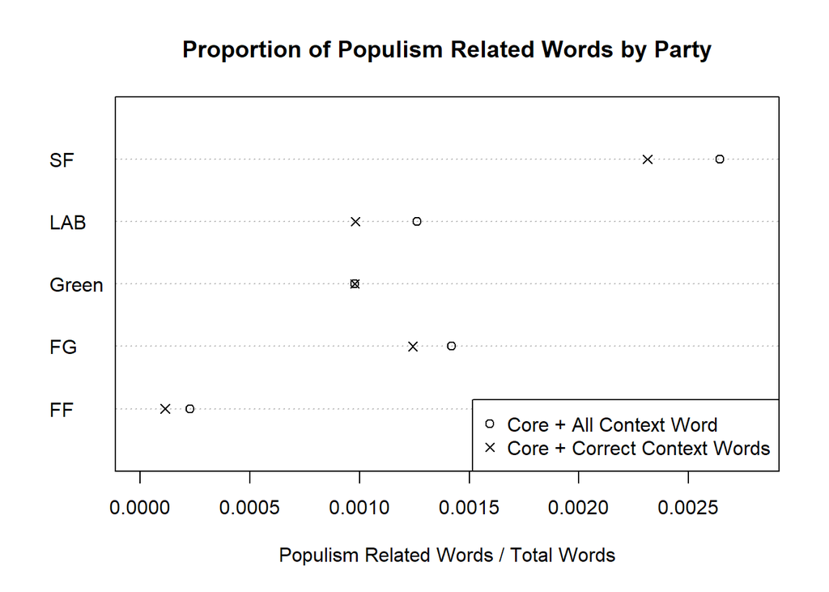

```
From the graph above, it is quite clear that SF is the party most prone to populism related words, and FF is the part least prone to populism related words.
```

```r
populismRatio <- ntoken(budgetDictDfm)/ntoken(budgetDfm)
populismRatio_corrected <- c(1, 7, 2, 7, 14)/ntoken(budgetDfm)

dotchart(populismRatio,
         labels = factor(names(ntoken(budgetDfm))),
         main = "Proportion of Populism Related Words by Party",
         xlab = "Populism Related Words / Total Words",
         xlim = c(0, 0.0028),
         pch = 1)
points(populismRatio_corrected , factor(names(ntoken(budgetDfm))), pch = 4)

legend(x = "bottomright",
       legend = c("Core + All Context Word", "Core + Correct Context Words"),
       pch = c(1, 4),
       col = c("black", "black"))
```

### Question 5

Here we will use k-means clustering to see if we can produce groupings by party of the 1984 US House of Representatives, based on their voting records from 16 votes. This data is the object `HouseVotes84` from the `mlbench` package. Since this is stored as a list of factors, use the following code to transform it into a method that will work with the `kmeans()` function.

```r
data(HouseVotes84, package = "mlbench")
HouseVotes84num <- as.data.frame(lapply(HouseVotes84[, -1], unclass))
HouseVotes84num[is.na(HouseVotes84num)] <- 0
set.seed(2)  # make sure you do this before step b below
```

1. What does each line of that code snippet do, and why was this operation needed? What is the `-1` indexing for?

   The first line of the code loads the data `HouseVotes84` from the package `mlbench`. The second line removes the class attributes of all but the first column (which is the party indicator) from `HouseVotes84`, then coerces it as a data frame and stores it into a variable `HouseVotes84num`. This changes it from a factor to numeric, and contains only the voting record for ease of operation later. The third line changes all `NA` records to 0 as pre-processing to allow clustering. At this step, a value of 0 simply indicate not voting yea. The forth line sets the random seed for the random number generator later. `-1` refers to negation of the first column, i.e. selecting all but the first column.
2. Perform a kmeans clustering on the votes only data, for 2 classes, after setting the seed to 2 as per above. Construct a table comparing the actual membership of the Congressperson’s party (you will find this as one of the variables in the `HouseVotes84` data) to the cluster assigned by the kmeans procedure. Report the
   1. accuracy
   2. precision
   3. recall

```r
HouseVotes84num.kmc <- kmeans(HouseVotes84num, 2)
HouseVotes84num.kmc.clus <- factor(HouseVotes84num.kmc$cluster, labels = c("1", "2"))
ref_clus <- factor(HouseVotes84[, 1], labels = c("1", "2"))

confusionMatrix(HouseVotes84num.kmc.clus, reference = ref_clus, mode = "prec_recall", positive = NULL)
```

```
## Confusion Matrix and Statistics
##
##           Reference
## Prediction   1   2
##          1 220  10
##          2  47 158
##
##                Accuracy : 0.869
##                  95% CI : (0.8336, 0.8992)
##     No Information Rate : 0.6138
##     P-Value [Acc > NIR] : < 2.2e-16
##
##                   Kappa : 0.7345
##  Mcnemar's Test P-Value : 1.858e-06
##
##               Precision : 0.9565
##                  Recall : 0.8240
##                      F1 : 0.8853
##              Prevalence : 0.6138
##          Detection Rate : 0.5057
##    Detection Prevalence : 0.5287
##       Balanced Accuracy : 0.8822
##
##        'Positive' Class : 1
##
```

```
From the output above, the clusters are assigned automatically. The automatic assignment of clusters is quite tricky, but it worked well for this case, as can be seen from the confusion matrix. An accuracy of 86.9% was obtained, with precision and recall being 95.65% and 82.4% respectively.
```

3. Repeat b twice more to produce three more confusion matrix tables, comparing the results. Are they the same? If not, why not?

```r
HouseVotes84num.kmc <- kmeans(HouseVotes84num, 2)
HouseVotes84num.kmc.clus <- factor(HouseVotes84num.kmc$cluster, labels = c("1", "2"))
ref_clus <- factor(HouseVotes84[, 1], labels = c("1", "2"))

confusionMatrix(HouseVotes84num.kmc.clus, reference = ref_clus)
```

```
## Confusion Matrix and Statistics
##
##           Reference
## Prediction   1   2
##          1  47 158
##          2 220  10
##
##                Accuracy : 0.131
##                  95% CI : (0.1008, 0.1664)
##     No Information Rate : 0.6138
##     P-Value [Acc > NIR] : 1.000000
##
##                   Kappa : -0.7155
##  Mcnemar's Test P-Value : 0.001704
##
##             Sensitivity : 0.17603
##             Specificity : 0.05952
##          Pos Pred Value : 0.22927
##          Neg Pred Value : 0.04348
##              Prevalence : 0.61379
##          Detection Rate : 0.10805
##    Detection Prevalence : 0.47126
##       Balanced Accuracy : 0.11778
##
##        'Positive' Class : 1
##
```

```r
HouseVotes84num.kmc <- kmeans(HouseVotes84num, 2)
HouseVotes84num.kmc.clus <- factor(HouseVotes84num.kmc$cluster, labels = c("1", "2"))
ref_clus <- factor(HouseVotes84[, 1], labels = c("1", "2"))

confusionMatrix(HouseVotes84num.kmc.clus, reference = ref_clus)
```

```
## Confusion Matrix and Statistics
##
##           Reference
## Prediction   1   2
##          1 174  95
##          2  93  73
##
##                Accuracy : 0.5678
##                  95% CI : (0.5198, 0.6149)
##     No Information Rate : 0.6138
##     P-Value [Acc > NIR] : 0.9777
##
##                   Kappa : 0.0864
##  Mcnemar's Test P-Value : 0.9419
##
##             Sensitivity : 0.6517
##             Specificity : 0.4345
##          Pos Pred Value : 0.6468
##          Neg Pred Value : 0.4398
##              Prevalence : 0.6138
##          Detection Rate : 0.4000
##    Detection Prevalence : 0.6184
##       Balanced Accuracy : 0.5431
##
##        'Positive' Class : 1
##
```

```r
HouseVotes84num.kmc <- kmeans(HouseVotes84num, 2)
HouseVotes84num.kmc.clus <- factor(HouseVotes84num.kmc$cluster, labels = c("1", "2"))
ref_clus <- factor(HouseVotes84[, 1], labels = c("1", "2"))

confusionMatrix(HouseVotes84num.kmc.clus, reference = ref_clus)
```

```
## Confusion Matrix and Statistics
##
##           Reference
## Prediction   1   2
##          1  47 158
##          2 220  10
##
##                Accuracy : 0.131
##                  95% CI : (0.1008, 0.1664)
##     No Information Rate : 0.6138
##     P-Value [Acc > NIR] : 1.000000
##
##                   Kappa : -0.7155
##  Mcnemar's Test P-Value : 0.001704
##
##             Sensitivity : 0.17603
##             Specificity : 0.05952
##          Pos Pred Value : 0.22927
##          Neg Pred Value : 0.04348
##              Prevalence : 0.61379
##          Detection Rate : 0.10805
##    Detection Prevalence : 0.47126
##       Balanced Accuracy : 0.11778
##
##        'Positive' Class : 1
##
```

[output not shown]